# ELM Model and statstics analysis

Hao Yuan

2023-03-29

# ELM modeling& statstics analysis by R

```r
#for data processing
library(tidyverse)
#for EDA
library(GGally)
```

```r
library(ggplot2)

#for ELM&regression
library(elmNNRcpp)
library(KernelKnn)
library(corrplot)
library(glmnet)
library(caret)
library(ELMR)
```

## Data Processing&EDA

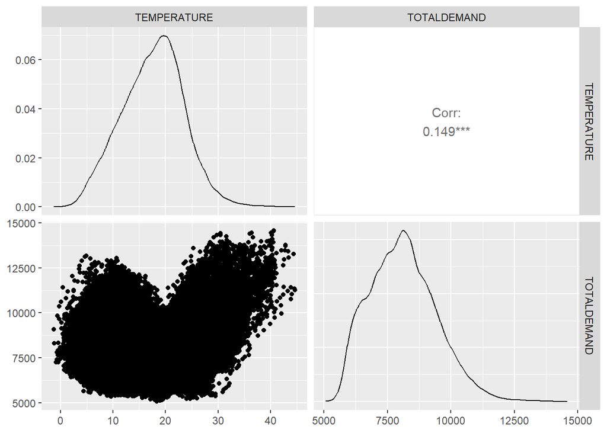

```r
#load the data
temp <- read.csv("temperature_nsw.csv")
demd<-read.csv("totaldemand_nsw.csv")

#Only preserve useful data
temp<-temp[,-1]
demd<-demd[,1:2]

#merge two dataframe into one
total<-merge(temp,demd,by="DATETIME")
total<-total[,2:3]
ggpairs(total)
```

```r
total=as.matrix(total)
```

## Key findings from EDA

· Normal distribution for temperature and total demand  
· A low correlation coefficient between temperature and total demand  
· Forecast of demand is not accuracy when later night and early morning.  
· The sum of delta of forecast and real demand is lower when extreme weather.

## ELM modeling

```r
set.seed(1000)
traindata<-total[sample(1:nrow(total),round(0.8*nrow(total))),]
testdata<-total[(nrow(traindata)+1):nrow(total),]
train_x<-as.matrix(traindata[,-ncol(traindata)])
train_y<-as.matrix(traindata[,ncol(traindata),drop=FALSE])
test_x<-as.matrix(testdata[,-ncol(testdata)])
test_y<-as.matrix(testdata[,ncol(testdata),drop=FALSE])


model<-elm_train(train_x,train_y,nhid=50,actfun='purelin',init_weights='normal_gaussian')
predict_y = elm_predict(model,test_x)
data.frame(rmse=sqrt(mean((predict_y-test_y)^2)),mape=mean(abs(predict_y-test_y)/test_y))
```

```
##       rmse      mape
## 1 2732.252 0.2529218
```

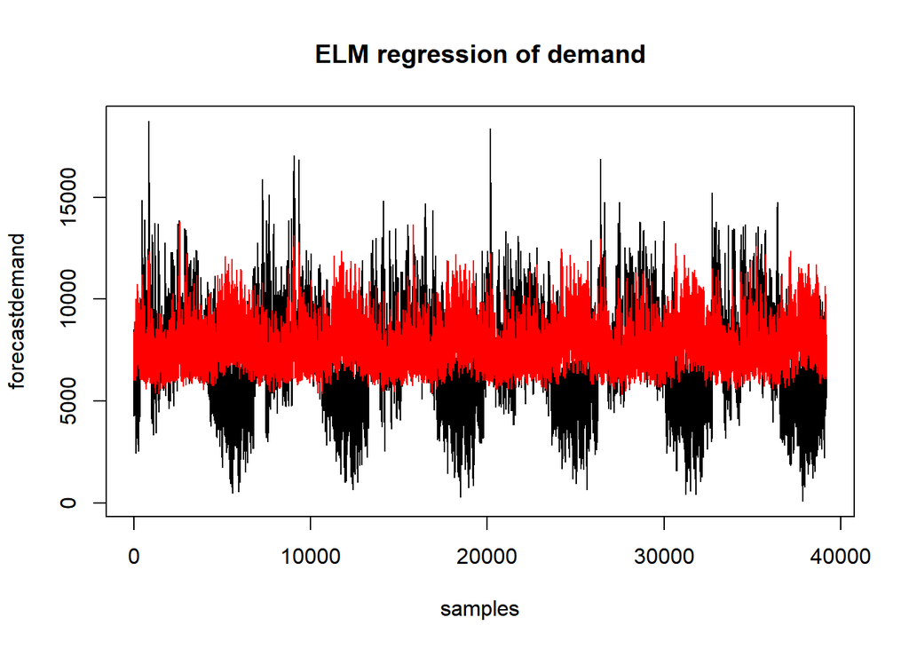

```r
plot(predict_y,type='l',xlab = 'samples',ylab = 'forecastdemand',main = 'ELM regression of demand')
lines(test_y,type = 'l',col="red")
```

According to the basic ELM(Extreme Learning Machine)model, we got the first plot and rmse of this model,2732. To make the model more efficient, we are going to make some more analysis.

### Statstics Analysis

```r
#polynomial regression
fit1<-lm(total[,2]~poly(total[,1],3))
summary(fit1)
```

```
##
## Call:
## lm(formula = total[, 2] ~ poly(total[, 1], 3))
##
## Residuals:
##     Min      1Q  Median      3Q     Max
## -6823.4  -927.1   -29.9   826.1  5166.0
##
## Coefficients:
##                       Estimate Std. Error t value Pr(>|t|)
## (Intercept)          8.112e+03  2.774e+00 2924.70   <2e-16 ***
## poly(total[, 1], 3)1 8.571e+04  1.228e+03   69.81   <2e-16 ***
## poly(total[, 1], 3)2 1.569e+05  1.228e+03  127.81   <2e-16 ***
## poly(total[, 1], 3)3 5.827e+04  1.228e+03   47.47   <2e-16 ***
## ---
## Signif. codes:  0 '***' 0.001 '**' 0.01 '*' 0.05 '.' 0.1 ' ' 1
##
## Residual standard error: 1228 on 195943 degrees of freedom
## Multiple R-squared:  0.1069, Adjusted R-squared:  0.1069
## F-statistic:  7821 on 3 and 195943 DF,  p-value: < 2.2e-16
```

From polynomial regression, we conclude that this model should include more features.

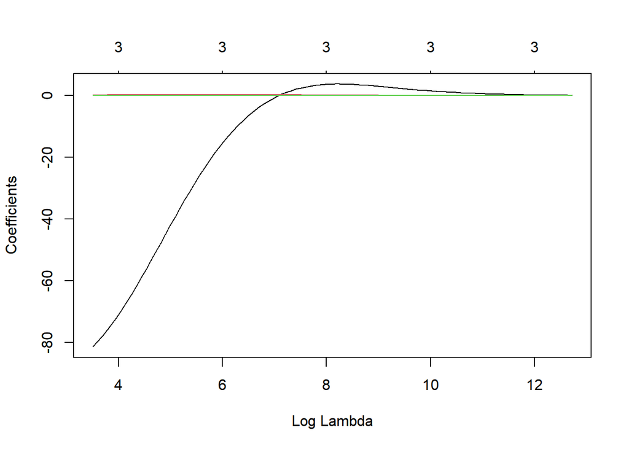

```r
#ridge regression

train<-cbind(train_x,train_x^2,train_x^3)
test<-cbind(test_x,test_x^2,test_x^3)
ridge=glmnet(x=train,y=train_y,family = 'gaussian',alpha = 0)
plot(ridge,xvar = 'lambda')
```

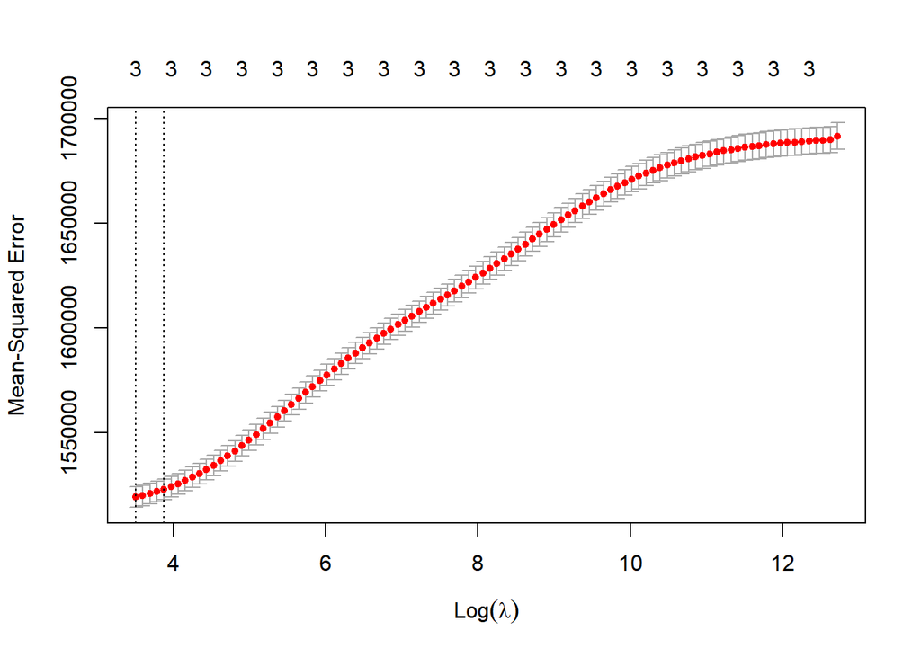

```r
set.seed(123)
cv.ridge=cv.glmnet(x=train,y=train_y,family='gaussian',alpha=0)
plot(cv.ridge)
```

```r
pre_ridge=predict(cv.ridge,newx=test)
rmse_ridge=sqrt(mean((pre_ridge-test_y)^2))
rmse_ridge
```

```
## [1] 1218.41
```

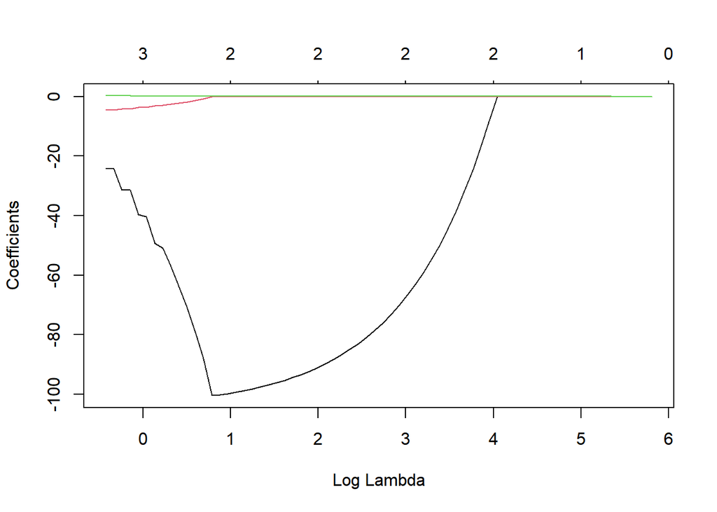

```r
#lasso regression

lasso=glmnet(x=train,y=train_y,family = 'gaussian',alpha = 1)
plot(lasso,xvar = 'lambda')
```

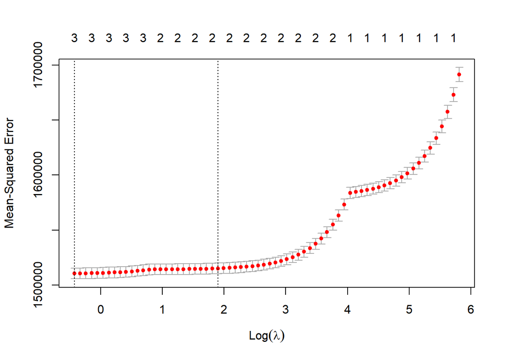

```r
set.seed(123)
cv.lasso=cv.glmnet(x=train,y=train_y,family='gaussian',alpha=1)
plot(cv.lasso)
```

```r
pre_lasso=predict(cv.lasso,newx=test)
rmse_lasso=sqrt(mean((pre_lasso-test_y)^2))
rmse_lasso
```

```
## [1] 1215.944
```

```r
#ELM model with more features

model<-elm_train(train,train_y,nhid=50,actfun='purelin',init_weights='normal_gaussian')
predict_y = elm_predict(model,test)
data.frame(rmse=sqrt(mean((predict_y-test_y)^2)),mape=mean(abs(predict_y-test_y)/test_y))
```

```
##       rmse      mape
## 1 1456.738 0.1404093
```

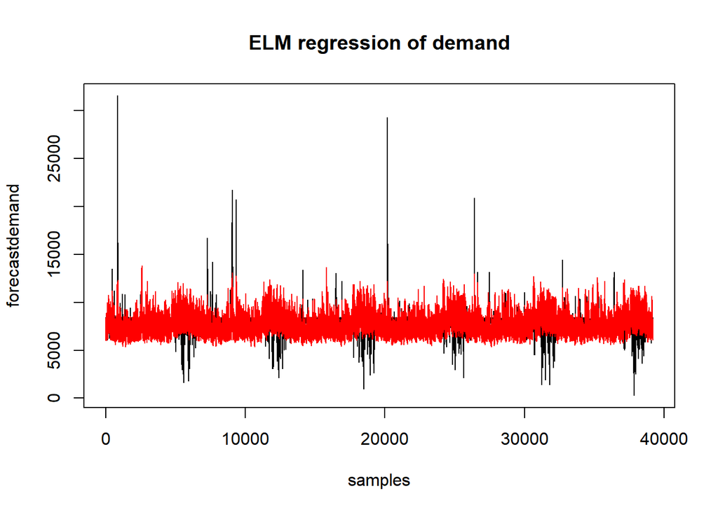

```r
plot(predict_y,type='l',xlab = 'samples',ylab = 'forecastdemand',main = 'ELM regression of demand')
lines(test_y,type = 'l',col="red")
```

After adding two power features, it seems like we get a better model but there is a special situation happens, a kind of overfitting. To avoid it, we usually use these steps:dropout,regularization,batch normalization and so on, for this model, we are going to use cross-validation to check if overfitting happens.

## Cross Validation

```r
#ELM with 10-folds(cross validation)
X<-cbind(total[,1],total[,1]^2,total[,1]^3)
Y<-as.matrix(total[,2])
data<-cbind(X,total[,2])

train.index <- sample(1:nrow(data), 0.8*nrow(data))
train.data <- data[train.index, ]
test.data <- data[-train.index, ]


elm_model <- function(X_train, Y_train, X_test) {
  elm <- elm_train(X_train, Y_train,nhid=50,actfun='purelin',init_weights='normal_gaussian')
  Y_pred <- elm_predict(elm,X_test)
  return(Y_pred)
}
k_fold_cv <- function(data, k) {
  mse <- rep(0, k)

  for(i in 1:k) {
    # split data
    folds <- cut(seq(1, nrow(data)), breaks = k, labels = FALSE)
    validation.index <- which(folds == i, arr.ind = TRUE)
    validation.data <- data[validation.index, ]
    train.data <- data[-validation.index, ]


    Y_pred <- elm_model(train.data[, -ncol(train.data)], as.matrix(train.data[, ncol(train.data)]),
                        validation.data[, -ncol(validation.data)])

    mse[i] <- sum((Y_pred - validation.data[, ncol(validation.data)])^2) / length(Y_pred)
  }

  cv_error <- mean(mse)

  return(cv_error)
}
cv_test <- k_fold_cv(train.data, 10)
print(cv_test)
```

```
## [1] 2046035
```

```r
cv_rmse <- sqrt(cv_test)
print(cv_rmse)
```

```
## [1] 1430.397
```

The RMSE of 10-folds cross validation reflects there is no overfitting on that ELM model.